# Problem Statement

Dengue fever is a viral infection that results in a serious, sometimes life threatening illness. It has no current vaccine and no current treatment regimen other than supportive care such as administration of fluids, pain and fever control. According to the World Health Organization (WHO), instances of dengue fever have increased over 30 times over a period of the last half century. The number of infected per year is in the upper 50 to 100 million individuals world wide (Descloux et al. 2012). It affects all population groups with an equal intensity but it is especially prevelant in poor urban areas with ineffective mosquito control policies. It is transmitted to human hosts by the Aedes aegypti (Asian tiger) mosquito. A human may develop an immunity to one serotype of the virus but still lack an effective immune response to the other three serotypes: DEN-1, DEN-2,DEN-3, etc. Unfortunately, subsequent infections have been shown to be more severe and life threatening. [(WHO)](http://www.who.int/denguecontrol/disease/en/).

Due to the pandemic nature of this virus and its severity, being able to forecast outbreaks down to the number of cases is an essential tool in the fight against this virus by allowing health officials allocate the resources necessary to affected areas. To that end, this project focuses on Dengue fever forecasting for the two cities Iquitos and San Juan using the combined environmental and case data for provided for both regions by [DrivenData](https://www.drivendata.org/competitions/44/dengai-predicting-disease-spread/page/80/).

Some factors not included explicitly with the data provided, but that have been shown to be predictive of dengue outbreaks are “…human population growth, accelerated urbanization, increased international transport, weakened public health infrastructure as well as a lack of effective vector control and disease surveillance”(Descloux et al. 2012). Possible further investigation into feature engineering or model tuning based off of these influential variables could be considered.

#### Libraries

This problem will require many different tools available to R. Noteably, the forecast package will provide most of the utility necessary to this problem.

#### Load and Examine the Structure of the Data

The data comes in a csv format. The labels are seperated from the training data and located in dengue_labels_train. Iquitos and San Juan are combined in the initial data structure and therefore must be split to ensure correct modeling and imputation. Iquitos has a training set of 520 observations across 24 variables not inlcuding the total cases. The Iquitos test set is 156 observations or 30 percent of the data. San Juan has more observations with a training size of 936 with the same number of variables. The San Juan test set is 260 observations or about 27 percent of the data. Included in the variables are a time index, measures of vegetation, temperature, humidity, and precipitation.

```r
#Training data, needed to reformat the string dtype into date.
dengue_features_train <-
  read.csv(
  "C:/Users/Alex/OneDrive/PredictiveAnalytics/Final/dengue_features_train.csv"
  )

#Training labels
dengue_labels_train <-
  read.csv(
  "C:/Users/Alex/OneDrive/PredictiveAnalytics/Final/dengue_labels_train.csv"
  )
#Test data
dengue_features_test <- read.csv("C:/Users/Alex/OneDrive/PredictiveAnalytics/Final/dengue_features_test.csv")

str(dengue_features_train)
```

```
## 'data.frame':    1456 obs. of  24 variables:
##  $ city                                 : Factor w/ 2 levels "iq","sj": 2 2 2 2 2 2 2 2 2 2 ...
##  $ year                                 : int  1990 1990 1990 1990 1990 1990 1990 1990 1990 1990 ...
##  $ weekofyear                           : int  18 19 20 21 22 23 24 25 26 27 ...
##  $ week_start_date                      : Factor w/ 1049 levels "1990-04-30","1990-05-07",..: 1 2 3 4 5 6 7 8 9 10 ...
##  $ ndvi_ne                              : num  0.1226 0.1699 0.0323 0.1286 0.1962 ...
##  $ ndvi_nw                              : num  0.104 0.142 0.173 0.245 0.262 ...
##  $ ndvi_se                              : num  0.198 0.162 0.157 0.228 0.251 ...
##  $ ndvi_sw                              : num  0.178 0.155 0.171 0.236 0.247 ...
##  $ precipitation_amt_mm                 : num  12.42 22.82 34.54 15.36 7.52 ...
##  $ reanalysis_air_temp_k                : num  298 298 299 299 300 ...
##  $ reanalysis_avg_temp_k                : num  298 298 299 299 300 ...
##  $ reanalysis_dew_point_temp_k          : num  292 294 295 295 296 ...
##  $ reanalysis_max_air_temp_k            : num  300 301 300 301 302 ...
##  $ reanalysis_min_air_temp_k            : num  296 296 297 297 298 ...
##  $ reanalysis_precip_amt_kg_per_m2      : num  32 17.9 26.1 13.9 12.2 ...
##  $ reanalysis_relative_humidity_percent : num  73.4 77.4 82.1 80.3 80.5 ...
##  $ reanalysis_sat_precip_amt_mm         : num  12.42 22.82 34.54 15.36 7.52 ...
##  $ reanalysis_specific_humidity_g_per_kg: num  14 15.4 16.8 16.7 17.2 ...
##  $ reanalysis_tdtr_k                    : num  2.63 2.37 2.3 2.43 3.01 ...
##  $ station_avg_temp_c                   : num  25.4 26.7 26.7 27.5 28.9 ...
##  $ station_diur_temp_rng_c              : num  6.9 6.37 6.49 6.77 9.37 ...
##  $ station_max_temp_c                   : num  29.4 31.7 32.2 33.3 35 34.4 32.2 33.9 33.9 33.9 ...
##  $ station_min_temp_c                   : num  20 22.2 22.8 23.3 23.9 23.9 23.3 22.8 22.8 24.4 ...
##  $ station_precip_mm                    : num  16 8.6 41.4 4 5.8 39.1 29.7 21.1 21.1 1.1 ...
```

```r
str(dengue_labels_train)
```

```
## 'data.frame':    1456 obs. of  4 variables:
##  $ city       : Factor w/ 2 levels "iq","sj": 2 2 2 2 2 2 2 2 2 2 ...
##  $ year       : int  1990 1990 1990 1990 1990 1990 1990 1990 1990 1990 ...
##  $ weekofyear : int  18 19 20 21 22 23 24 25 26 27 ...
##  $ total_cases: int  4 5 4 3 6 2 4 5 10 6 ...
```

```r
str(dengue_features_test)
```

```
## 'data.frame':    416 obs. of  24 variables:
##  $ city                                 : Factor w/ 2 levels "iq","sj": 2 2 2 2 2 2 2 2 2 2 ...
##  $ year                                 : int  2008 2008 2008 2008 2008 2008 2008 2008 2008 2008 ...
##  $ weekofyear                           : int  18 19 20 21 22 23 24 25 26 27 ...
##  $ week_start_date                      : Factor w/ 269 levels "2008-04-29","2008-05-06",..: 1 2 3 4 5 6 7 8 9 10 ...
##  $ ndvi_ne                              : num  -0.0189 -0.018 -0.0015 NA 0.0568 ...
##  $ ndvi_nw                              : num  -0.0189 -0.0124 NA -0.0199 0.0398 ...
##  $ ndvi_se                              : num  0.1027 0.082 0.1511 0.1243 0.0623 ...
##  $ ndvi_sw                              : num  0.0912 0.0723 0.0915 0.1257 0.0759 ...
##  $ precipitation_amt_mm                 : num  78.6 12.56 3.66 0 0.76 ...
##  $ reanalysis_air_temp_k                : num  298 298 299 300 300 ...
##  $ reanalysis_avg_temp_k                : num  299 299 299 300 300 ...
##  $ reanalysis_dew_point_temp_k          : num  295 294 295 294 295 ...
##  $ reanalysis_max_air_temp_k            : num  301 301 302 303 302 ...
##  $ reanalysis_min_air_temp_k            : num  296 297 296 297 297 ...
##  $ reanalysis_precip_amt_kg_per_m2      : num  25.37 21.83 4.12 2.2 4.36 ...
##  $ reanalysis_relative_humidity_percent : num  78.8 78.2 78.3 73 74.1 ...
##  $ reanalysis_sat_precip_amt_mm         : num  78.6 12.56 3.66 0 0.76 ...
##  $ reanalysis_specific_humidity_g_per_kg: num  15.9 15.8 16.7 15.8 16.1 ...
##  $ reanalysis_tdtr_k                    : num  3.13 2.57 4.43 4.34 3.54 ...
##  $ station_avg_temp_c                   : num  26.5 26.1 27.9 28.1 27.6 ...
##  $ station_diur_temp_rng_c              : num  7.06 5.56 7.79 6.27 7.09 ...
##  $ station_max_temp_c                   : num  33.3 30 32.8 33.3 33.3 32.8 31.1 34.4 32.8 31.1 ...
##  $ station_min_temp_c                   : num  21.7 22.2 22.8 24.4 23.3 25 23.3 24.4 23.9 25 ...
##  $ station_precip_mm                    : num  75.2 34.3 3 0.3 84.1 27.7 91.7 0.3 28.7 2.9 ...
```

#### San Juan and Iquitos

What we see from the statistics below is that even though there are half the observations for Iquitos, there are 8 times as many cases in San Juan. The population of Iquitos is larger at approximately 437,000 while San Juan clocks in at 389,000. The overall population growth for San Juan post year 2000 has been in decline in contrast to Iquitos which has been steadily growing since the 80’s [populationy.city](http://population.city/peru/iquitos/). Examining a physical map of the two locations using Google Maps, we see that Iquitos is surrounded by several different water features including lakes and various rivers, one of which is the Amazon. San Juan, by contrast is a purely costal city surrounded by ocean. As the location of the city is important in determining its average climate, we note that Iquitos is 3.7 degrees south of the equator while San Juan is 18.46 degrees north.

```r
#Lets look at the total number of observations for both:
table(dengue_features_train[,1])
```

```
##
##  iq  sj
## 520 936
```

```r
#Okay, so we have a lot more data points for sj. Lets take a look at the number of cases per city.
dengue_labels_train %>% group_by(city) %>% summarise_each(funs(sum))
```

```
## # A tibble: 2 × 4
##     city    year weekofyear total_cases
##   <fctr>   <int>      <int>       <int>
## 1     iq 1042600      13782        3934
## 2     sj 1870902      24807       31993
```

```r
#Test split
sj_test <- dengue_features_test %>% filter(dengue_features_test$city == 'sj')
sj_test$total_cases <- NA
iq_test <- dengue_features_test %>% filter(city == 'iq')
iq_test$total_cases <- NA
#Split the cities apart into separate training sets
#San Juan
sj_train <- dengue_features_train %>% filter(city == 'sj')
sj_train_labels <- dengue_labels_train %>% filter(city == 'sj')
sj_time_index <- sj_train$week_start_date
sj_train$total_cases <- sj_train_labels$total_cases
sj_total <- rbind.data.frame(sj_test,sj_train)

summary(sj_total)
```

```
##  city           year        weekofyear      week_start_date
##  iq:   0   Min.   :1990   Min.   : 1.00   2008-04-29:   1
##  sj:1196   1st Qu.:1996   1st Qu.:13.75   2008-05-06:   1
##            Median :2001   Median :26.50   2008-05-13:   1
##            Mean   :2001   Mean   :26.50   2008-05-20:   1
##            3rd Qu.:2007   3rd Qu.:39.25   2008-05-27:   1
##            Max.   :2013   Max.   :53.00   2008-06-03:   1
##                                           (Other)   :1190
##     ndvi_ne            ndvi_nw            ndvi_se
##  Min.   :-0.46340   Min.   :-0.45610   Min.   :-0.01553
##  1st Qu.:-0.00931   1st Qu.: 0.00795   1st Qu.: 0.13776
##  Median : 0.05112   Median : 0.05904   Median : 0.17601
##  Mean   : 0.05045   Mean   : 0.06073   Mean   : 0.17752
##  3rd Qu.: 0.10710   3rd Qu.: 0.10751   3rd Qu.: 0.21365
##  Max.   : 0.50040   Max.   : 0.64900   Max.   : 0.39313
##  NA's   :234        NA's   :60         NA's   :20
##     ndvi_sw         precipitation_amt_mm reanalysis_air_temp_k
##  Min.   :-0.06346   Min.   :  0.00       Min.   :295.9
##  1st Qu.: 0.12521   1st Qu.:  0.76       1st Qu.:298.2
##  Median : 0.16271   Median : 19.67       Median :299.4
##  Mean   : 0.16315   Mean   : 33.52       Mean   :299.2
##  3rd Qu.: 0.20042   3rd Qu.: 49.81       3rd Qu.:300.3
##  Max.   : 0.38142   Max.   :390.60       Max.   :302.2
##  NA's   :20         NA's   :11           NA's   :8
##  reanalysis_avg_temp_k reanalysis_dew_point_temp_k
##  Min.   :296.1         Min.   :289.6
##  1st Qu.:298.3         1st Qu.:293.9
##  Median :299.4         Median :295.5
##  Mean   :299.3         Mean   :295.2
##  3rd Qu.:300.4         3rd Qu.:296.5
##  Max.   :302.2         Max.   :297.8
##  NA's   :8             NA's   :8
##  reanalysis_max_air_temp_k reanalysis_min_air_temp_k
##  Min.   :297.8             Min.   :292.6
##  1st Qu.:300.4             1st Qu.:296.3
##  Median :301.6             Median :297.5
##  Mean   :301.4             Mean   :297.4
##  3rd Qu.:302.4             3rd Qu.:298.4
##  Max.   :304.3             Max.   :299.9
##  NA's   :8                 NA's   :8
```

[output cut: 17 more lines]

```
##  Min.   :1.357     Min.   :22.84      Min.   :4.043
##  1st Qu.:2.171     1st Qu.:25.87      1st Qu.:6.054
##  Median :2.471     Median :27.28      Median :6.600
##  Mean   :2.532     Mean   :27.06      Mean   :6.626
##  3rd Qu.:2.814     3rd Qu.:28.23      3rd Qu.:7.157
##  Max.   :4.429     Max.   :30.27      Max.   :9.914
##  NA's   :8         NA's   :8          NA's   :8
##  station_max_temp_c station_min_temp_c station_precip_mm  total_cases
##  Min.   :26.70      Min.   :17.80      Min.   :  0.0     Min.   :  0.00
##  1st Qu.:30.60      1st Qu.:21.70      1st Qu.:  6.9     1st Qu.:  9.00
##  Median :31.70      Median :22.80      Median : 18.6     Median : 19.00
##  Mean   :31.62      Mean   :22.71      Mean   : 28.4     Mean   : 34.18
##  3rd Qu.:32.80      3rd Qu.:23.90      3rd Qu.: 38.9     3rd Qu.: 37.00
##  Max.   :35.60      Max.   :26.70      Max.   :305.9     Max.   :461.00
##  NA's   :8          NA's   :8          NA's   :8         NA's   :260
```

```r
#Inquintos
iq_train <- dengue_features_train %>% filter(city == 'iq')
iq_train_labels <- dengue_labels_train %>% filter(city == 'iq')
iq_train$total_cases <- iq_train_labels$total_cases
iq_time_index <- iq_train$week_start_date
iq_total <- rbind.data.frame(iq_test,iq_train)
summary(iq_total)
```

```
##  city          year        weekofyear      week_start_date
##  iq:676   Min.   :2000   Min.   : 1.00   2008-04-29:  1
##  sj:  0   1st Qu.:2003   1st Qu.:13.75   2008-05-06:  1
##           Median :2006   Median :26.00   2008-05-13:  1
##           Mean   :2006   Mean   :26.46   2008-05-20:  1
##           3rd Qu.:2010   3rd Qu.:39.00   2008-05-27:  1
##           Max.   :2013   Max.   :53.00   2008-06-03:  1
##                                          (Other)   :670
##     ndvi_ne           ndvi_nw           ndvi_se           ndvi_sw
##  Min.   :0.06173   Min.   :0.03586   Min.   :0.02988   Min.   :0.06418
##  1st Qu.:0.20194   1st Qu.:0.18663   1st Qu.:0.19656   1st Qu.:0.20684
##  Median :0.26364   Median :0.24143   Median :0.25036   Median :0.26561
##  Mean   :0.26457   Mean   :0.24615   Mean   :0.25209   Mean   :0.27036
##  3rd Qu.:0.31981   3rd Qu.:0.29950   3rd Qu.:0.30230   3rd Qu.:0.32806
##  Max.   :0.50836   Max.   :0.46480   Max.   :0.53831   Max.   :0.54602
##  NA's   :3         NA's   :3         NA's   :3         NA's   :3
##  precipitation_amt_mm reanalysis_air_temp_k reanalysis_avg_temp_k
##  Min.   :  0.00       Min.   :294.6         Min.   :294.9
##  1st Qu.: 38.99       1st Qu.:297.1         1st Qu.:298.2
##  Median : 58.66       Median :297.8         Median :299.1
##  Mean   : 62.78       Mean   :297.8         Mean   :299.1
##  3rd Qu.: 83.76       3rd Qu.:298.6         3rd Qu.:300.1
##  Max.   :210.83       Max.   :301.9         Max.   :303.3
##  NA's   :4            NA's   :4             NA's   :4
##  reanalysis_dew_point_temp_k reanalysis_max_air_temp_k
##  Min.   :290.1               Min.   :300.0
##  1st Qu.:294.6               1st Qu.:305.2
##  Median :295.9               Median :306.9
##  Mean   :295.5               Mean   :307.1
##  3rd Qu.:296.5               3rd Qu.:308.7
##  Max.   :298.4               Max.   :314.1
##  NA's   :4                   NA's   :4
##  reanalysis_min_air_temp_k reanalysis_precip_amt_kg_per_m2
##  Min.   :286.2             Min.   :  0.00
##  1st Qu.:291.9             1st Qu.: 26.12
##  Median :293.0             Median : 49.34
##  Mean   :292.8             Mean   : 61.09
##  3rd Qu.:294.1             3rd Qu.: 79.38
##  Max.   :296.0             Max.   :362.03
##  NA's   :4                 NA's   :4
```

[output cut: 17 more lines]

```
##  Min.   :21.40      Min.   : 5.200          Min.   :29.60
##  1st Qu.:27.00      1st Qu.: 9.533          1st Qu.:33.20
##  Median :27.60      Median :10.633          Median :34.00
##  Mean   :27.53      Mean   :10.607          Mean   :33.99
##  3rd Qu.:28.10      3rd Qu.:11.667          3rd Qu.:34.90
##  Max.   :30.80      Max.   :15.800          Max.   :42.20
##  NA's   :47         NA's   :47              NA's   :15
##  station_min_temp_c station_precip_mm  total_cases
##  Min.   :14.20      Min.   :  0.00    Min.   :  0.000
##  1st Qu.:20.60      1st Qu.: 15.00    1st Qu.:  1.000
##  Median :21.30      Median : 38.80    Median :  5.000
##  Mean   :21.17      Mean   : 55.93    Mean   :  7.565
##  3rd Qu.:22.00      3rd Qu.: 77.00    3rd Qu.:  9.000
##  Max.   :24.20      Max.   :543.30    Max.   :116.000
##  NA's   :15         NA's   :19        NA's   :156
```

```r
rm(dengue_features_test)
rm(dengue_features_test)
rm(dengue_labels_train)
```

### Missing values and data cleaning

Just from doing a quick summary of the data, we can see that there are multiple missing values across all of the variables except for the cases. Using the pMiss function found here: [RBloggers](https://www.r-bloggers.com/imputing-missing-data-with-r-mice-package/), we can easily check and see if the percentage of missing values exceeds n% per variable. The NDVI_NE variable is missing a significant number of values. Does this mean that there was no vegetation in the area or adequate sampling was obstructed from the clouds? According to the [wikipedia](https://en.wikipedia.org/wiki/Normalized_Difference_Vegetation_Index) article on NDVI, this measurement should be used with a high degree of caution due to the measurement uncertainty introduced by climate conditions. Here is where it gets tricky: both cities are different locations in the globe so we almost certainly shouldn’t impute all the data at once. Even though NVDI is missing quite a few values for San Juan, we’re missing much less for Iquitos so unfortunately we’ll be losing good data dropping the variable from Iquitos; however, in order to keep the width of the dataset consistent perhaps the best strategy is to drop the variable altogether. In this case, we decided to use mutliple imputation and keep the variable to observe the performance.

```
##                                  city
##                             0.0000000
##                                  year
##                             0.0000000
##                            weekofyear
##                             0.0000000
##                       week_start_date
##                             0.0000000
##                               ndvi_ne
##                            19.5652174
##                               ndvi_nw
##                             5.0167224
##                               ndvi_se
##                             1.6722408
##                               ndvi_sw
##                             1.6722408
##                  precipitation_amt_mm
##                             0.9197324
##                 reanalysis_air_temp_k
##                             0.6688963
##                 reanalysis_avg_temp_k
##                             0.6688963
##           reanalysis_dew_point_temp_k
##                             0.6688963
##             reanalysis_max_air_temp_k
##                             0.6688963
##             reanalysis_min_air_temp_k
##                             0.6688963
##       reanalysis_precip_amt_kg_per_m2
##                             0.6688963
##  reanalysis_relative_humidity_percent
##                             0.6688963
##          reanalysis_sat_precip_amt_mm
##                             0.9197324
## reanalysis_specific_humidity_g_per_kg
##                             0.6688963
##                     reanalysis_tdtr_k
##                             0.6688963
##                    station_avg_temp_c
##                             0.6688963
##               station_diur_temp_rng_c
##                             0.6688963
##                    station_max_temp_c
##                             0.6688963
##                    station_min_temp_c
##                             0.6688963
##                     station_precip_mm
##                             0.6688963
##                           total_cases
##                            21.7391304
```

```
##                                  city
##                              0.000000
##                                  year
##                              0.000000
##                            weekofyear
##                              0.000000
##                       week_start_date
##                              0.000000
##                               ndvi_ne
##                              0.443787
##                               ndvi_nw
##                              0.443787
##                               ndvi_se
##                              0.443787
##                               ndvi_sw
##                              0.443787
##                  precipitation_amt_mm
##                              0.591716
##                 reanalysis_air_temp_k
##                              0.591716
##                 reanalysis_avg_temp_k
##                              0.591716
##           reanalysis_dew_point_temp_k
##                              0.591716
##             reanalysis_max_air_temp_k
##                              0.591716
##             reanalysis_min_air_temp_k
##                              0.591716
##       reanalysis_precip_amt_kg_per_m2
##                              0.591716
##  reanalysis_relative_humidity_percent
##                              0.591716
##          reanalysis_sat_precip_amt_mm
##                              0.591716
## reanalysis_specific_humidity_g_per_kg
##                              0.591716
##                     reanalysis_tdtr_k
##                              0.591716
##                    station_avg_temp_c
##                              6.952663
##               station_diur_temp_rng_c
##                              6.952663
##                    station_max_temp_c
##                              2.218935
##                    station_min_temp_c
##                              2.218935
##                     station_precip_mm
##                              2.810651
##                           total_cases
##                             23.076923
```

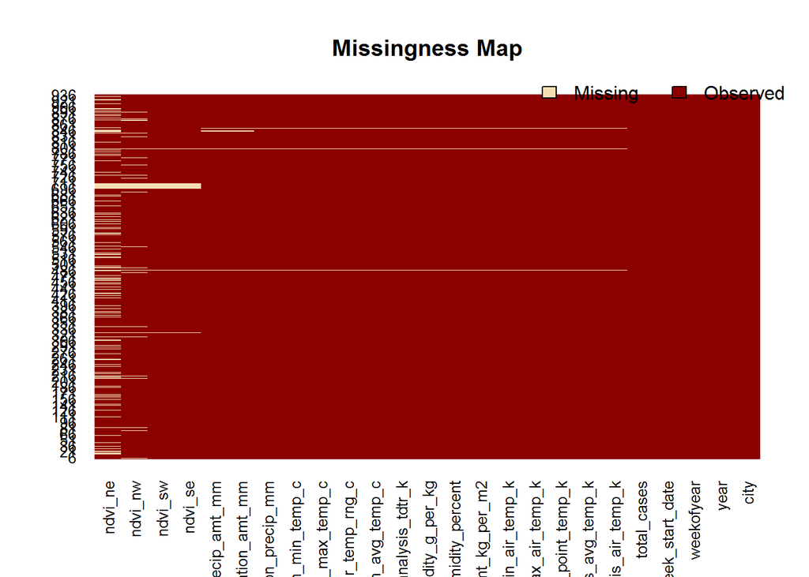

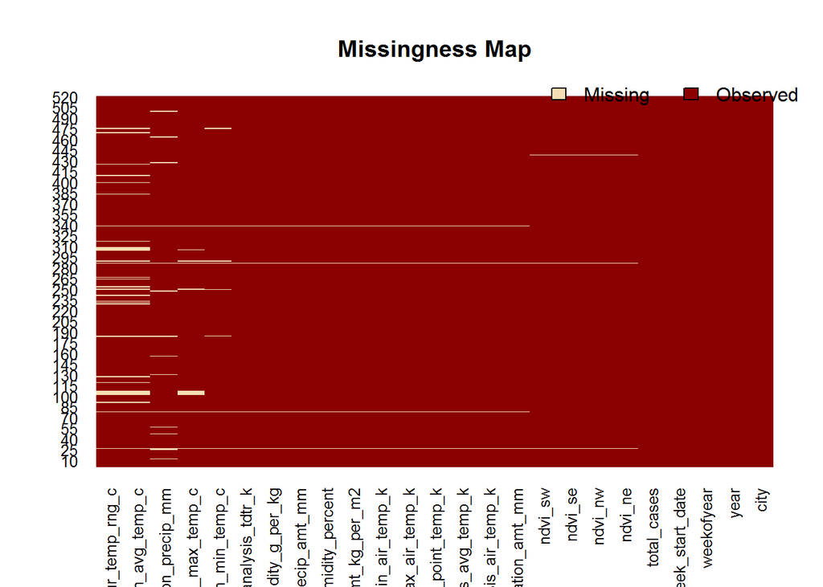

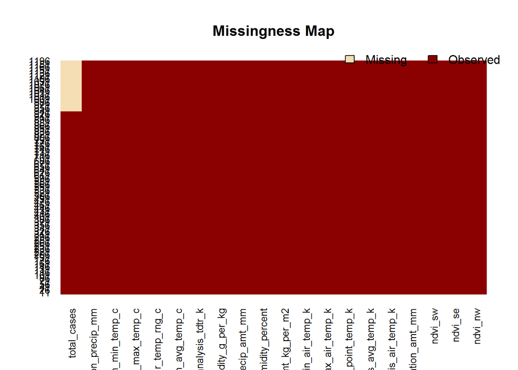

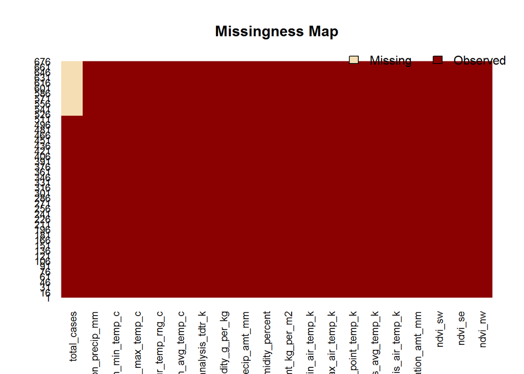

#Exploratory Data Analysis

In this section I’m looking at the normality of the predictor variables as well as the distribution of the cases to identify any other concerns. As far as the distribution of the cases go, it is mostly clustered around very small values with a long right tail. Interestingly, the distribution of the predictor variables such as temperature or the NDVI coefficient are quite normal and correlatted. One of the things we can look for in our predictors is the possibility of feature engineering. Information taken from [Mosquito World](http://www.mosquitoworld.net/about-mosquitoes/species/) on the species of mosquito that carries denngue reveals that this mosquito is such an effective vector for disease because, although it is homophilic and prefers human hosts 90% of the time(Focks DA 1998), it will substitute birds and small mammals when human blood meals are unavailable. As mentioned earlier, the Asian tiger, being a floodwater mosquito, is influenced only partially by the precipitation rates in the areas in which it inhabits. Additionally, it has been shown that the overall virus life cycle is heavily influenced by temperature. The optimal temperature for outbreak conditions being at 38 degrees C. Temperatures above this cause a rapid decay in the probability of an epidemic(Focks DA 1998). Temperatures below 24C slow the mosquito breeding rates and any area which reaches freezing temperatures tends to be protected from the spread of the Asian tiger algother although there are exceptions(Focks DA 1998).

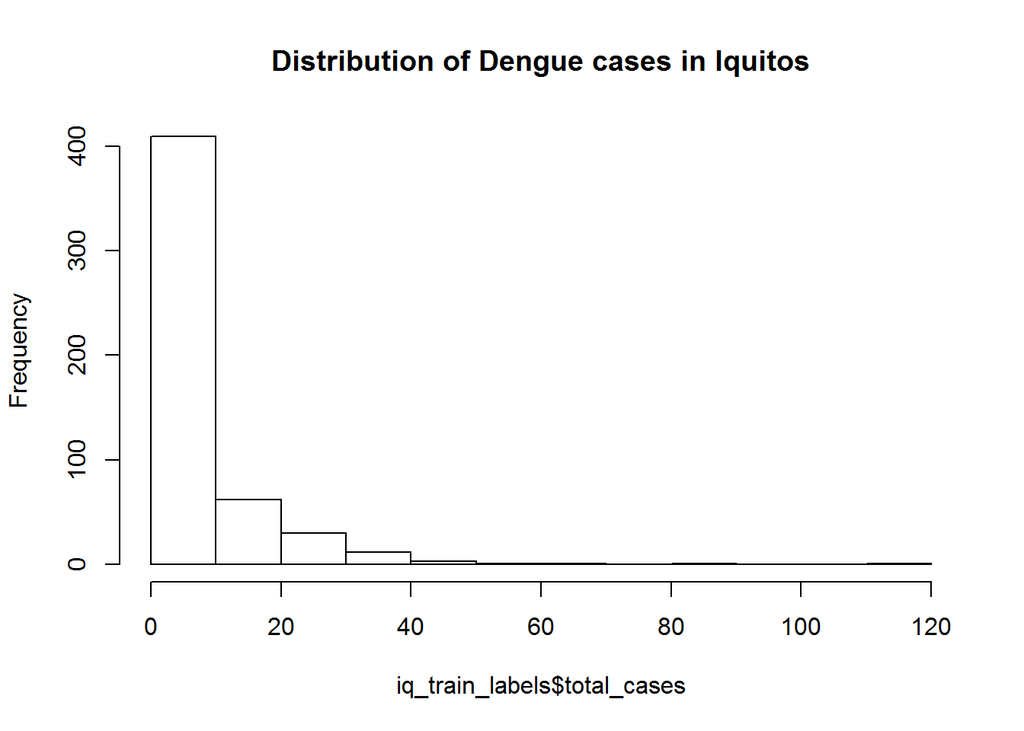

```r
#Examine the distribution of cases
hist(iq_train_labels$total_cases, main ='Distribution of Dengue cases in Iquitos')
```

```r
summary(sj_train_labels$total_cases)
```

```
##    Min. 1st Qu.  Median    Mean 3rd Qu.    Max.
##    0.00    9.00   19.00   34.18   37.00  461.00
```

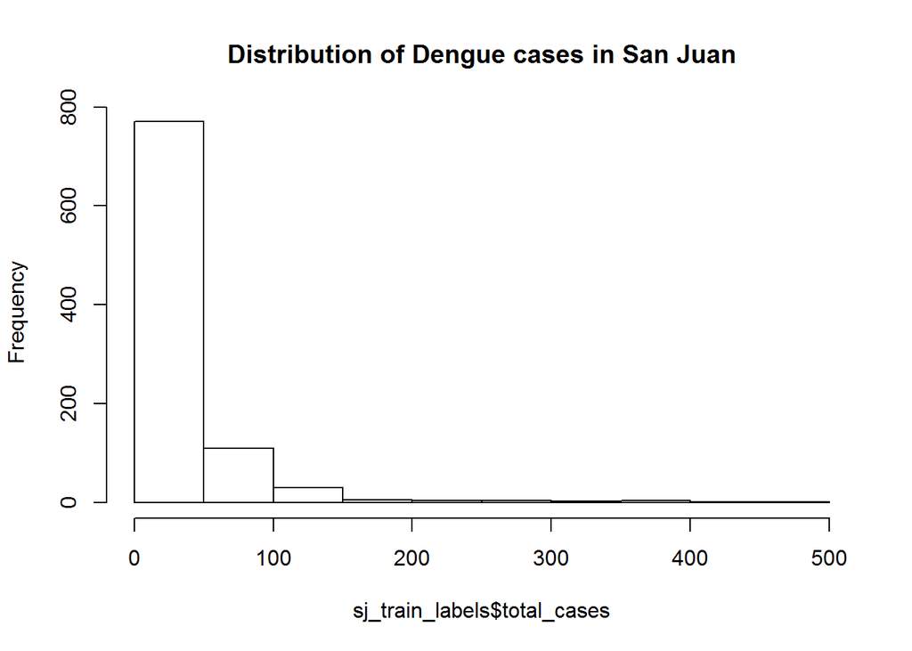

```r
hist(sj_train_labels$total_cases, main = 'Distribution of Dengue cases in San Juan')
```

```r
summary(iq_train_labels$total_cases)
```

```
##    Min. 1st Qu.  Median    Mean 3rd Qu.    Max.
##   0.000   1.000   5.000   7.565   9.000 116.000
```

```r
##RESOURCE SELECTION
##It makes sense that vegetation is correlated across the quadrants.
library(ResourceSelection)
```

```
## ResourceSelection 0.3-2   2017-02-28
```

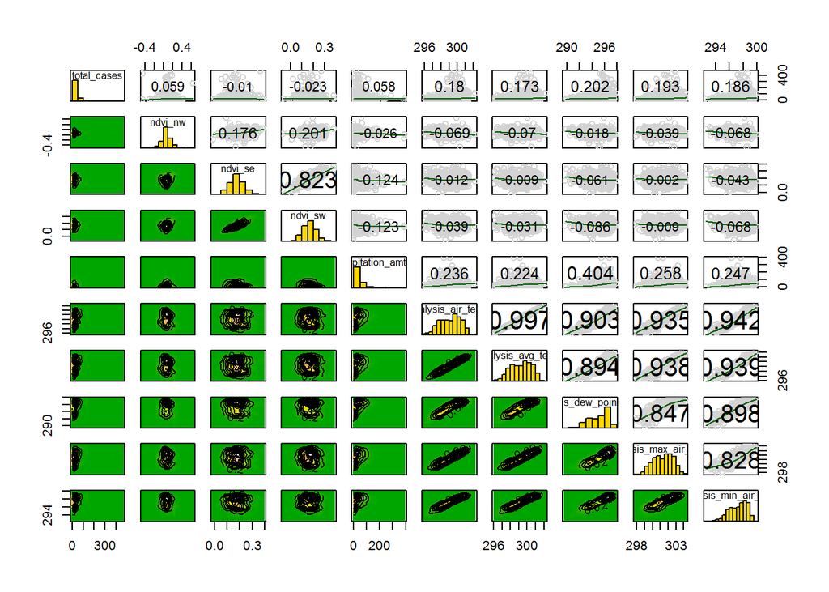

```r
kdepairs(sj_train[1:10])
```

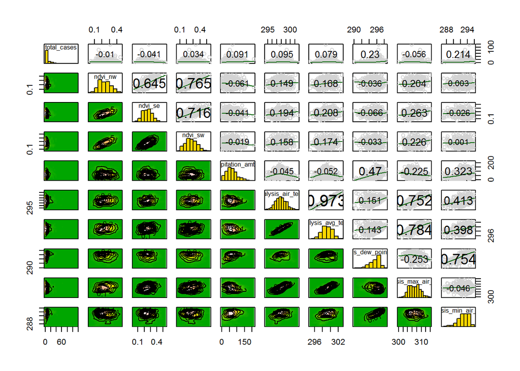

```r
kdepairs(iq_train[1:10])
```

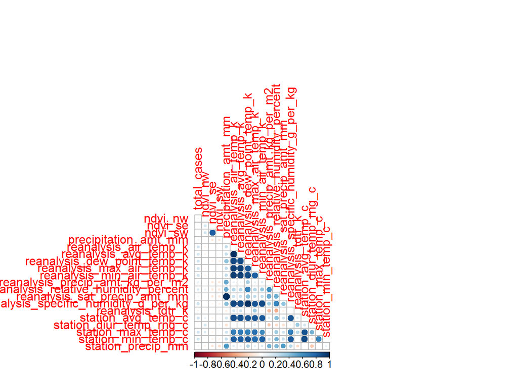

```r
#Look at a corrplot of the features
library(corrplot)
sj_train %>% cor(use = 'pairwise.complete.obs') %>% corrplot(., type="lower", method="circle",diag=FALSE)
```

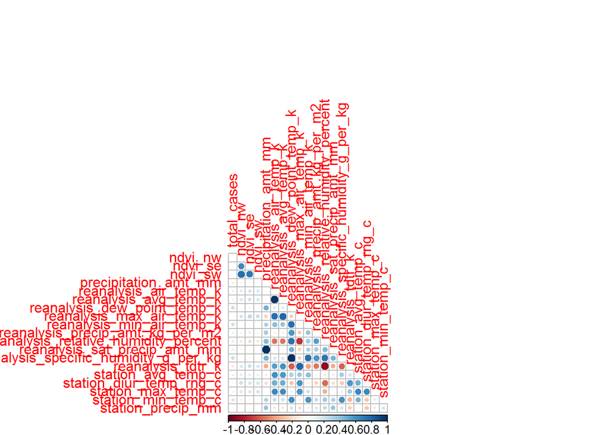

```r
iq_train %>% cor(use = 'pairwise.complete.obs') %>% corrplot(., type="lower", method="circle",diag=FALSE)
```

### Examining time series

Up until now we’ve ignored the fact that this is time series data. There are many ways to do transform the data into a time indexed object in R, but the method we chose was to create a time series (ts) object using the start date for each city respectively. It was important to isolate only the cases/labels in this processes or the ts does not work properly. Plotting the time series against the number of cases reveals that the data is fairly seasonal with the highest number of cases occuring around Decemeber-January for both locations. Looking at the ACF and PACF reveals some interesting information about the autocorrelations present in the data. Our auto.arima model will probably need to difference the data at least once to acheive a more stationary time series. Decomposing the time series further reveals the seasonal and trend components underlying the time series, it also shows the random component of the data. More importantly, the trend line for each of the cities shows the long term shock a level shift introduces on the model. This might affect the forecast performance because according to Smith, “Sudden level shifts can dramatically affect the forecasting performance of a time series model. Models that assume a constant level produce biased forecasts after a level shift. Such bias often dictates the overall performance of forecasting models (Smith 2005).”

```r
#Time series
sj_train_ts<- ts(sj_train$total_cases,frequency = 52, start=c(1990,04,30))
##Example using 0s sj_train_cases <- ts(sj_train$cases,frequency = 52, start=c(1990,04,30))
iq_train_ts<- ts(iq_train$total_cases,frequency = 52, start = c(2000,07,01))

#XTS allows us to use more granular plots and dygraph tools.
sj_xts <- xts(sj_train,order.by = as.Date(sj_time_index[1:936]))
iq_xts <- xts(iq_train,order.by = as.Date(iq_time_index[1:520]))


#Do some prelimary plotting of the time series
dygraph(sj_xts[,c(1,16,20)], main = 'San Juan cases versus temp and precip') %>% dyRangeSelector()
```

[interactive chart not shown]

```r
dygraph(iq_xts[,c(1,16,20)], main = 'Iquitos cases versus temp and precip') %>% dyRangeSelector()
```

[interactive chart not shown]

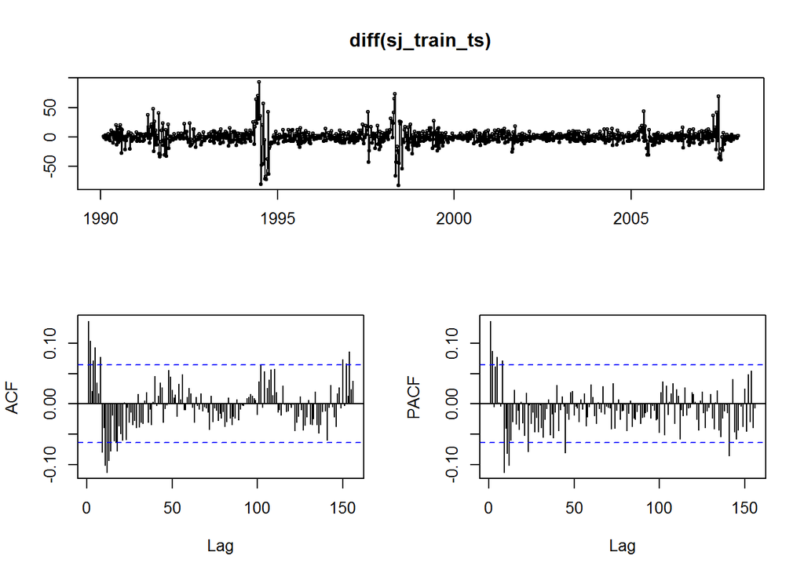

```r
tsdisplay(diff(sj_train_ts))
```

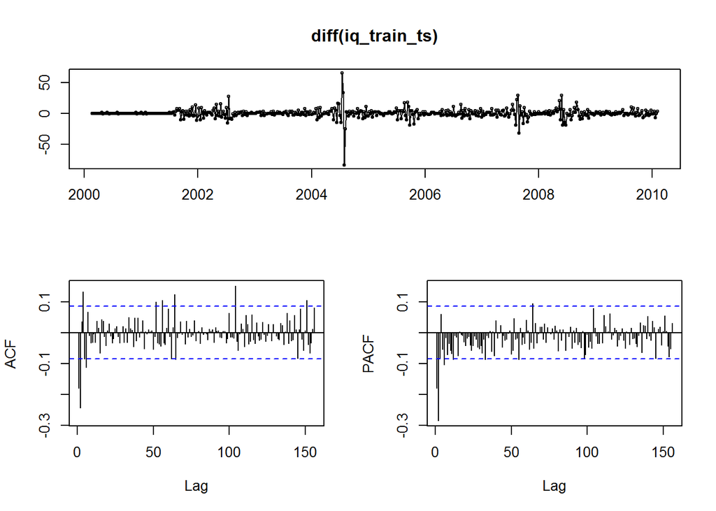

```r
tsdisplay(diff(iq_train_ts))
```

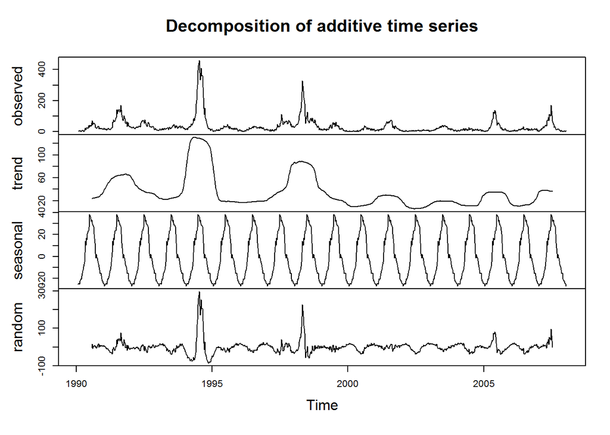

```r
#Take a look at the decomposed time series
plot(decompose(sj_train_ts))
```

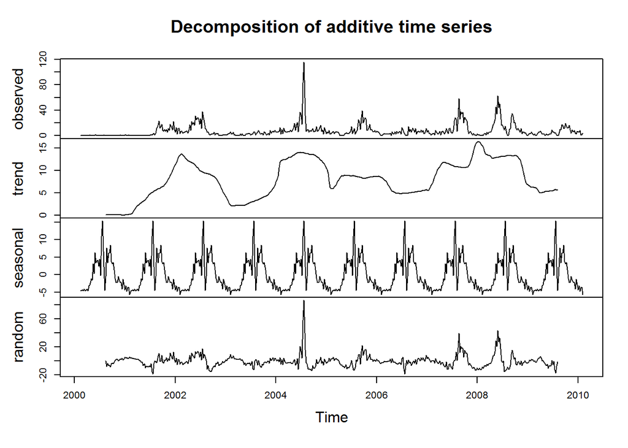

```r
plot(decompose(iq_train_ts))
```

```r
#Create a plotting function to view the distribution of forecast errors
plotForecastErrors <- function(forecasterrors)
  {
     # make a histogram of the forecast errors:
     mybinsize <- IQR(forecasterrors)/4
     mysd   <- sd(forecasterrors)
     mymin  <- min(forecasterrors) - mysd*5
     mymax  <- max(forecasterrors) + mysd*3
     # generate normally distributed data with mean 0 and standard deviation mysd
     mynorm <- rnorm(10000, mean=0, sd=mysd)
     mymin2 <- min(mynorm)
     mymax2 <- max(mynorm)
     if (mymin2 < mymin) { mymin <- mymin2 }
     if (mymax2 > mymax) { mymax <- mymax2 }
     # make a red histogram of the forecast errors, with the normally distributed data overlaid:
     mybins <- seq(mymin, mymax, mybinsize)
     hist(forecasterrors, col="red", freq=FALSE, breaks=mybins)
     # freq=FALSE ensures the area under the histogram = 1
     # generate normally distributed data with mean 0 and standard deviation mysd
     myhist <- hist(mynorm, plot=FALSE, breaks=mybins)
     # plot the normal curve as a blue line on top of the histogram of forecast errors:
     points(myhist$mids, myhist$density, type="l", col="blue", lwd=2)
  }

#Build a quick 1-off model to look at the residuals.
test_model <-auto.arima(sj_train_ts)
Box.test(test_model$residuals, lag = 20, type = 'Ljung-Box')
```

```
##
##  Box-Ljung test
##
## data:  test_model$residuals
## X-squared = 46.537, df = 20, p-value = 0.00068
```

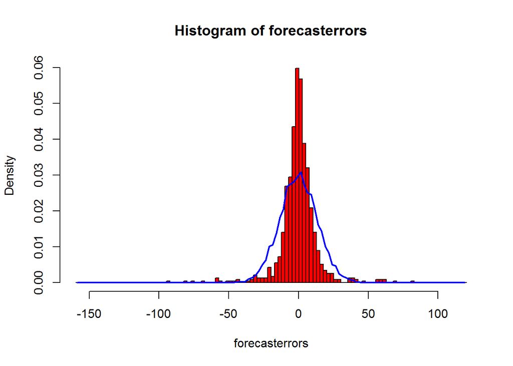

```r
plotForecastErrors(test_model$residuals)
```

```r
#This is probably going overboard, but I have read that when it rains too much, it actually washes away mosquitos, so I binned the precipitation amount just to get an intution of how much rain sj gets.
table(cut(sj_train$precipitation_amt_mm, c(-Inf,35,200,300,Inf),labels = c("dry","average", 'high','drowning')))
```

```
##
##      dry  average     high drowning
##      586      339        9        2
```

# Modeling

The first attempt at modeling using a neural net forecast yielded a submission score of 35.00 for the competition. That wasn’t great, so next I tried a baseline ARIMA model using only the time series without any external regressors. Obviously, this performed even worse than my neural net model. I then tried an auto.arima to see if a simpler model would yield better results. Interestingly, before removing the outliers, this yielded quite a few negative values in the forecast which was a problem since it is impossible to have negative cases of dengue fever. I noticed that these values were very different from my neural network forecast, so I decided that perhaps an ensemble model would work better than either. I created two models for each city and then averaged their forecasts using a simple mean. The result was the best submission so far of 26+. After some research on how to remove level shifts and reduce bias in a time series a system, I used the tsclean function from the forecast package to remove outliers that caused undue shocks to the time series. This allowed the forecasts to avoid the trap of overpredicting based off cases that weren’t typical of the data. Next I noticed that the ARIMA model worked well for Iquitos but it produced a fairly unimpressive result for San Juan; therefore, I used the ARIMA model for Iquitos and the neural net for San Juan without any averaging. This produced a submission result of 25.7500.

```r
sj_clean_ts <- tsclean(sj_train_ts)
iq_clean_ts <- tsclean(iq_train_ts)

#Neural net
fit_sj_nnet <- nnetar(sj_clean_ts, size = 10,repeats = 50, decay = .01, p = 1, xreg=sj_train[-1])
fit_iq <-nnetar(iq_clean_ts,size = 10, repeats = 50, p = 1, decay = .01, xreg = iq_train[-1])
#Auto Arima
fit_iq_arima <- auto.arima(iq_clean_ts, allowdrift = TRUE, xreg = iq_train[-1])
fit_sj_arima <- auto.arima(sj_clean_ts, allowdrift = TRUE, xreg = sj_train[-1])
#SES just for fun
#fit_ses_sj <- ses(sj_train_ts,initial = 'optimal', h =260)
#fit_ses_iq <- ses(iq_train_ts,initial = 'optimal', nrow(iq_test))

#Build multiple predictions
sj_arima_forecast <- forecast(fit_sj_arima, h = 260, xreg = sj_test)
sj_forecast_nnet <- forecast.nnetar(fit_sj_nnet, bootstrap = TRUE,h = 260, xreg = sj_test, PI =TRUE)
#Test with seasonal adjustment
sj_stl_arima_forecast <- stlf(sj_train_ts, method = 'arima', xreg = sj_train$reanalysis_avg_temp_k, newxreg = sj_test$reanalysis_avg_temp_k, h = 260)

iq_forecast <- forecast.nnetar(fit_iq, bootstrap = TRUE, h = nrow(iq_test), xreg = iq_test, PI = TRUE)
iq_forecast_arima <- forecast(fit_iq_arima, h = nrow(iq_test), xreg = iq_test)


plot(fit_iq_arima$x, col = 'red')
lines(fitted(fit_iq_arima),col = 'blue')

plot(fit_sj_arima$x, col = 'red')
lines(fitted(fit_sj_arima),col = 'blue')

par(mfrow=c(2,2))
plot(iq_forecast, main = 'NNETAR forecast of the Iquitos test data')
plot(iq_forecast_arima, main = 'ARIMA forecast of the Iquitos test data')
plot(sj_arima_forecast, main = 'ARIMA forecast of the San Juan test data')
plot(sj_forecast_nnet, main = 'NNETAR forecast of the San Juan test data')
```

[output not shown]

### Predictions

To build my submissions, I simply save all of the forecasts for both cities to CSV, then I copy the respective values into the submission format file provided.

```r
write.csv(sj_arima_forecast,"sj_arima_forecast.csv")
write.csv(sj_forecast_nnet,"sj_nnet_forecast_bts.csv")
write.csv(sj_stl_arima_forecast, 'sj_stl_arima_forecast.csv')

write.csv(iq_forecast,"iq_forecast_nnet_bts.csv")
write.csv(iq_forecast_arima,"iq_forecast_arima.csv")
```

### Cleaning, Modeling, and Predicting with Python

Using Python I was able to create two different types of models. First the data was separated into San Juan and Iquitoes sets and the NA values were interpolated. Several plots were made for exploring the data sets. The first model was a GLM model using a Negative Binomial family parameter. With this model I was able to score a 25.8173. This is an ok score. Next I did some research and came across LSTM or Long Short Term Memory models. These models are supposed to perform well with time series data.In a traditional recurrent neural network, during the gradient back-propagation phase, the gradient signal can end up being multiplied many times (as many as the number of timesteps) by the weight matrix associated with the connections between the neurons of the recurrent hidden layer. This means that, the magnitude of weights in the transition matrix can have a strong impact on the learning process.(Graves 2008)(Gers, Schmidhuber, and Cummins 2000)(Hochreiter and Urgen Schmidhuber 1997) Further reading from a deep learning tutorial:

> “If the weights in this matrix are small (or, more formally, if the leading eigenvalue of the weight matrix is smaller than 1.0), it can lead to a situation called vanishing gradients where the gradient signal gets so small that learning either becomes very slow or stops working altogether. It can also make more difficult the task of learning long-term dependencies in the data. Conversely, if the weights in this matrix are large (or, again, more formally, if the leading eigenvalue of the weight matrix is larger than 1.0), it can lead to a situation where the gradient signal is so large that it can cause learning to diverge. This is often referred to as exploding gradients. These issues are the main motivation behind the LSTM model which introduces a new structure called a memory cell. A memory cell is composed of four main elements: an input gate, a neuron with a self-recurrent connection (a connection to itself), a forget gate and an output gate. The self-recurrent connection has a weight of 1.0 and ensures that, barring any outside interference, the state of a memory cell can remain constant from one timestep to another. The gates serve to modulate the interactions between the memory cell itself and its environment. The input gate can allow incoming signal to alter the state of the memory cell or block it. On the other hand, the output gate can allow the state of the memory cell to influence other neurons or prevent it. Finally, the forget gate can modulate the memory cell’s self-recurrent connection, allowing the cell to remember or forget its previous state, as needed.”[LTSM Networks](http://deeplearning.net/tutorial/lstm.html)

So far the best score achieve with the LSTM model is 28.1106. With better cleaning and removal of outliers I believe this model could do even better. But do to time constraints this will have to do for now. Below you will find all the code needed to replicate my results.

```python
from __future__ import print_function
from __future__ import division
import seaborn as sns
import numpy as np
import pandas as pd
import matplotlib.pyplot as plt
import math
from keras.utils.np_utils import to_categorical
from keras.models import Sequential
from keras.layers import Dense , Dropout
from keras.layers import LSTM
from sklearn.preprocessing import MinMaxScaler
from sklearn.metrics import mean_absolute_error
from statsmodels.tools import eval_measures
import statsmodels.formula.api as smf
import statsmodels.api as sm
from sklearn.preprocessing import StandardScaler
from sklearn import preprocessing
from sklearn.preprocessing import LabelEncoder
from sklearn.ensemble import RandomForestClassifier
```

```python
# load the provided data
train_features = pd.read_csv('D:\Predictive Analysis\Final DengAI\dengue_features_train.csv', index_col=[0,1,2])

train_labels = pd.read_csv('D:\Predictive Analysis\Final DengAI\dengue_labels_train.csv', index_col=[0,1,2])


# Seperate data for San Juan
sj_train_features = train_features.loc['sj']
sj_train_labels = train_labels.loc['sj']

# Separate data for Iquitos
iq_train_features = train_features.loc['iq']
iq_train_labels = train_labels.loc['iq']

print('San Juan')
print('features: ', sj_train_features.shape)
print('labels  : ', sj_train_labels.shape)

print('\nIquitos')
print('features: ', iq_train_features.shape)
print('labels  : ', iq_train_labels.shape)

sj_train_features.head()


# Remove `week_start_date` string.
sj_train_features.drop('week_start_date', axis=1, inplace=True)
iq_train_features.drop('week_start_date', axis=1, inplace=True)

# Null check
pd.isnull(sj_train_features).any()


(sj_train_features
     .ndvi_ne
     .plot
     .line(lw=0.8))

plt.title('Vegetation Index over Time')
plt.xlabel('Time')
```

```python
sj_train_features = sj_train_features.interpolate()
iq_train_features = iq_train_features.interpolate()

print('San Juan')
print('mean: ', sj_train_labels.mean()[0])
print('var :', sj_train_labels.var()[0])

print('\nIquitos')
print('mean: ', iq_train_labels.mean()[0])
print('var :', iq_train_labels.var()[0])

sj_train_labels.hist()
iq_train_labels.hist()
```

```python
sj_train_features['total_cases'] = sj_train_labels.total_cases
iq_train_features['total_cases'] = iq_train_labels.total_cases
```

```python
# compute the correlations
sj_correlations = sj_train_features.corr()
iq_correlations = iq_train_features.corr()

# plot san juan
sj_corr_heat = sns.heatmap(sj_correlations)
plt.title('San Juan Variable Correlations')

# plot iquitos
iq_corr_heat = sns.heatmap(iq_correlations)
plt.title('Iquitos Variable Correlations')
```

```python
# San Juan
(sj_correlations
     .total_cases
     .drop('total_cases') # don't compare with myself
     .sort_values(ascending=False)
     .plot
     .barh())
```

```python
# Iquitos
(iq_correlations
     .total_cases
     .drop('total_cases') # don't compare with myself
     .sort_values(ascending=False)
     .plot
     .barh())
```

```python
def preprocess_data(data_path, labels_path=None):
    # load data and set index to city, year, weekofyear
    df = pd.read_csv(data_path, index_col=[0, 1, 2])

    # select features we want
    features = ['reanalysis_specific_humidity_g_per_kg',
                 'reanalysis_dew_point_temp_k',
                 'station_avg_temp_c',
                 'station_min_temp_c']
    df = df[features]

    # fill missing values
    df.fillna(method='ffill', inplace=True)

    # add labels to dataframe
    if labels_path:
        labels = pd.read_csv(labels_path, index_col=[0, 1, 2])
        df = df.join(labels)

    # separate san juan and iquitos
    sj = df.loc['sj']
    iq = df.loc['iq']

    return sj, iq
```

```python
sj_train, iq_train = preprocess_data('D:\Predictive Analysis\Final DengAI\dengue_features_train.csv', labels_path="D:\Predictive Analysis\Final DengAI\dengue_labels_train.csv")
```

```python
print(sj_train.describe())
```

```python
print(iq_train.describe())
```

```python
#make the labels a float
sj_label = sj_train_labels.values
sj_label = sj_label.astype('float32')

iq_label = iq_train_labels.values
iq_label = iq_label.astype('float32')
```

```python
# normalize the SJ dataset
scaler_sj = MinMaxScaler(feature_range=(0, 1))
sj_train = scaler_sj.fit_transform(sj_train)
# normalize the IQ dataset
scaler_iq = MinMaxScaler(feature_range=(0, 1))
iq_train = scaler_iq.fit_transform(iq_train)
```

```python
#function to make t and t-1 sets
def create_dataset(dataset, look_back=1):
    dataX, dataY = [], []
    for i in range(len(dataset)-look_back-1):
        a = dataset[i:(i+look_back), 0]
        dataX.append(a)
        dataY.append(dataset[i + look_back, 0])
    return np.array(dataX), np.array(dataY)
```

```python
#create t and t-1 datasets
look_back = 1
trainX, trainY = create_dataset(sj_train, look_back)
testX, testY = create_dataset(sj_label, look_back)

iq_trainXX, iq_trainYY = create_dataset(iq_train, look_back)
iq_testXX, iq_testYY = create_dataset(iq_label, look_back)
```

```python
# reshape input to be [samples, time steps, features]
trainX = np.reshape(trainX, (trainX.shape[0],1, trainX.shape[1]))
trainY = np.reshape(trainY, (trainY.shape[0], 1, 1))

iq_trainXX = np.reshape(iq_trainXX, (iq_trainXX.shape[0], 1, iq_trainXX.shape[1]))
iq_trainYY = np.reshape(iq_trainYY, (iq_trainYY.shape[0], 1, 1))
```

```python
#LSTM model
model = Sequential()
model.add(LSTM(4, input_shape=(1, look_back)))
model.add(Dense(1))
model.compile(loss='mean_absolute_error', optimizer='sgd')

sj_model = model.fit(trainY, testX, nb_epoch=100, batch_size=1, verbose=0,validation_split=0.1)
iq_model = model.fit(iq_trainYY, iq_testXX, nb_epoch=100, batch_size=1, verbose=0,validation_split=0.1)
```

```python
#load test data then scale, transform, and reshape
sj_test, iq_test = preprocess_data('D:\Predictive Analysis\Final DengAI\dengue_features_test.csv')
sj_test = scaler_sj.fit_transform(sj_test)
sj_testX, sj_testY = create_dataset(sj_test, look_back)

sj_testX = np.reshape(sj_testX, (sj_testX.shape[0], 1, sj_testX.shape[1]))
sj_testY = np.reshape(sj_testY, (sj_testY.shape[0], 1, 1))
```

```python
#make predictions for SJ
sj_predictionsX = sj_model.model.predict(sj_testX)
sj_predictionsY = sj_model.model.predict(sj_testY)
```

```python
#repeat process for IQ
iq_test = scaler_iq.fit_transform(iq_test)
iq_testX, iq_testY = create_dataset(iq_test, look_back)

iq_testX = np.reshape(iq_testX, (iq_testX.shape[0], 1, iq_testX.shape[1]))
iq_testY = np.reshape(iq_testY, (iq_testY.shape[0], 1, 1))

iq_predictionsX = iq_model.model.predict(iq_testX)
iq_predictionsY = iq_model.model.predict(iq_testY)
```

```python
#make a submission file
submissionX = pd.read_csv("D:\Predictive Analysis\Final DengAI\submission_format.csv", index_col=[0, 1, 2])
submissionY = pd.read_csv("D:\Predictive Analysis\Final DengAI\submission_format.csv", index_col=[0, 1, 2])
full_predictionsX = np.concatenate([sj_predictionsX, iq_predictionsX])
full_predictionsY = np.concatenate([sj_predictionsY, iq_predictionsY])
a = iq_predictionsX.mean()
b = iq_predictionsY.mean()
#for some reason the prediction was 4 short so I added the mean to the end to make it the correct length
full_predictionsX = np.append(full_predictionsX,[a,a,a,a])
full_predictionsY = np.append(full_predictionsY,[b,b,b,b])
submissionX.total_cases = full_predictionsX.astype('int')
submissionY.total_cases = full_predictionsY.astype('int')
submissionX.to_csv("D:\Predictive Analysis\Final DengAI\LSTM_submissionX.csv")
submissionY.to_csv("D:\Predictive Analysis\Final DengAI\LSTM_submissionY.csv")
```

Code taken from the official DengAI benchmark [tutorial](https://shaulab.github.io/DrivenData/DengAI/Benchmark.html).

```python
#steps for the GLM model

sj_train, iq_train = preprocess_data('D:\Predictive Analysis\Final DengAI\dengue_features_train.csv', labels_path="D:\Predictive Analysis\Final DengAI\dengue_labels_train.csv")

sj_train_subtrain = sj_train.head(800)
sj_train_subtest = sj_train.tail(sj_train.shape[0] - 800)

iq_train_subtrain = iq_train.head(400)
iq_train_subtest = iq_train.tail(iq_train.shape[0] - 400)


#make a model
def get_best_model(train, test):
    # Step 1: specify the form of the model
    model_formula = "total_cases ~ 1 + " \
                    "reanalysis_specific_humidity_g_per_kg + " \
                    "reanalysis_dew_point_temp_k + " \
                    "station_min_temp_c + " \
                    "station_avg_temp_c"

    grid = 10 ** np.arange(-8, -3, dtype=np.float64)

    best_alpha = []
    best_score = 1000

    # Step 2: Find the best hyper parameter, alpha
    for alpha in grid:
        model = smf.glm(formula=model_formula,
                        data=train,
                        family=sm.families.NegativeBinomial(alpha=alpha))

        results = model.fit()
        predictions = results.predict(test).astype(int)
        score = eval_measures.meanabs(predictions, test.total_cases)

        if score < best_score:
            best_alpha = alpha
            best_score = score

    print('best alpha = ', best_alpha)
    print('best score = ', best_score)

    # Step 3: refit on entire dataset
    full_dataset = pd.concat([train, test])
    model = smf.glm(formula=model_formula,
                    data=full_dataset,
                    family=sm.families.NegativeBinomial(alpha=best_alpha))

    fitted_model = model.fit()
    return fitted_model

sj_best_model = get_best_model(sj_train_subtrain, sj_train_subtest)
iq_best_model = get_best_model(iq_train_subtrain, iq_train_subtest)

figs, axes = plt.subplots(nrows=2, ncols=1)

# plot sj
sj_train['fitted'] = sj_best_model.fittedvalues
sj_train.fitted.plot(ax=axes[0], label="Predictions")
sj_train.total_cases.plot(ax=axes[0], label="Actual")

# plot iq
iq_train['fitted'] = iq_best_model.fittedvalues
iq_train.fitted.plot(ax=axes[1], label="Predictions")
iq_train.total_cases.plot(ax=axes[1], label="Actual")

plt.suptitle("Dengue Predicted Cases vs. Actual Cases")
plt.legend()


sj_test, iq_test = preprocess_data('D:/Predictive Analysis/Final DengAI/dengue_features_test.csv')

sj_predictions = sj_best_model.predict(sj_test).astype(int)
iq_predictions = iq_best_model.predict(iq_test).astype(int)

submission = pd.read_csv("D:/Predictive Analysis/Final DengAI/submission_format.csv",
                         index_col=[0, 1, 2])

submission.total_cases = np.concatenate([sj_predictions, iq_predictions])
submission.to_csv("D:/Predictive Analysis/Final DengAI/GLM_dengue.csv")
```

# Final Notes and Learning Outcomes

After trying various feature combinations and even using PCA against the data, the model did not improve even though the forecasts look ‘reasonable’ when plotted. To improve this model, it may be necessary to exclude the outliers that occur in both San Juan and Iquitos without any support from the environmental data, doing so may improve the overall models for both cities because the forecasts are typically too high. In addition, the population data for San Juan shows a marked decrease in population in the order of -10% per year starting from 2000. This means fewer human hosts for the virus and a overall lower infection rate. To adjust for this population shift, it may be necessary to build in another variable for pre and post 2000.

# References

LSTM Networks for Sentiment Analysis. (n.d.). Retrieved May 08, 2017, from http://deeplearning.net/tutorial/lstm.html

What is dengue? (n.d.). Retrieved May 08, 2017, from http://www.who.int/denguecontrol/disease/en/

Iquitos population (n.d.) Retrieved May 08, 2017, from http://population.city/peru/iquitos/

Descloux, Elodie, Morgan Mangeas, Christophe Eugène Menkes, Matthieu Lengaigne, Anne Leroy, Temaui Tehei, Laurent Guillaumot, et al. 2012. “Climate-based models for understanding and forecasting dengue epidemics.” *PLoS Neglected Tropical Diseases* 6 (2). doi:10.1371/journal.pntd.0001470.

Focks DA, Jetten TH Patz JA Martens WJM. 1998. “Dengue Fever Epidemic Potential as Projected by General Circulation Models of Global Climate Change.” *Environmental Health Perspectives* 106 (3): 147–53. doi:10.1289/ehp.98106147.

Gers, Felix Alexander, Jürgen Schmidhuber, and Fred Cummins. 2000. “Learning to forget: continual prediction with LSTM.” *Neural Computation* 12 (10): 2451–71. doi:10.1162/089976600300015015.

Graves, Alex. 2008. “Supervised Sequence Labelling with Recurrent Neural Networks.” *Image Rochester NY*, 124. doi:10.1007/978-3-642-24797-2.

Hochreiter, Sepp, and J Urgen Schmidhuber. 1997. “LONG SHORT-TERM MEMORY.” *Neural Computation* 9 (8): 1735–80. doi:10.1162/neco.1997.9.8.1735.

Smith, Aaron. 2005. “Forecasting in the presence of level shifts.” *Journal of Forecasting* 24 (8): 557–74. doi:10.1002/for.968.